# Fraud Detection Project

## 4. Advanced Model — XGBoost

```r
library(xgboost)
library(pROC)

set.seed(123)

# =========================
# 1. fraud_data
# =========================
df <- fraud_data

# Only keep target = 0/1
df <- df[df$target %in% c(0, 1), ]
df$target <- as.numeric(df$target)

# =========================
# 2. Non-numeric variables → Secure integer encoding
# =========================
for (col in names(df)) {
  if (!is.numeric(df[[col]])) {
    df[[col]] <- as.numeric(as.factor(df[[col]]))
  }
}

# Remove NA
df <- df[complete.cases(df), ]

# =========================
# 3. sampling
# =========================
if (nrow(df) > 100000) {
  df <- df[sample(nrow(df), 100000), ]
}

# =========================
# 4. Train / Test split
# =========================
n <- nrow(df)
idx <- sample(seq_len(n), size = floor(0.7 * n))

train_df <- df[idx, ]
test_df  <- df[-idx, ]

x_train <- as.matrix(train_df[, setdiff(names(train_df), "target")])
y_train <- train_df$target

x_test  <- as.matrix(test_df[, setdiff(names(test_df), "target")])
y_test  <- test_df$target

# =========================
# 5. Class imbalance weights
# =========================
scale_pos_weight <- sum(y_train == 0) / sum(y_train == 1)

# =========================
# 6. XGBoost Training
# =========================
dtrain <- xgb.DMatrix(data = x_train, label = y_train)
dtest  <- xgb.DMatrix(data = x_test,  label = y_test)

params <- list(
  objective = "binary:logistic",
  eval_metric = "auc",
  max_depth = 6,
  eta = 0.1,
  subsample = 0.8,
  colsample_bytree = 0.8,
  scale_pos_weight = scale_pos_weight
)

xgb_model <- xgb.train(
  params = params,
  data = dtrain,
  nrounds = 150,
  verbose = 0
)

# Train AUC (overfitting check)
train_prob <- predict(xgb_model, dtrain)
roc_train <- roc(y_train, train_prob)
cat("Train AUC =", as.numeric(auc(roc_train)), "\n")
```

```
## Train AUC = 1
```

```r
# =========================
# 7. Prediction & ROC-AUC
# =========================
xgb_prob <- predict(xgb_model, dtest)

roc_xgb <- roc(y_test, xgb_prob)
auc_xgb <- as.numeric(auc(roc_xgb))

cat("XGBoost ROC-AUC =", auc_xgb, "\n")
```

```
## XGBoost ROC-AUC = 0.9722981
```

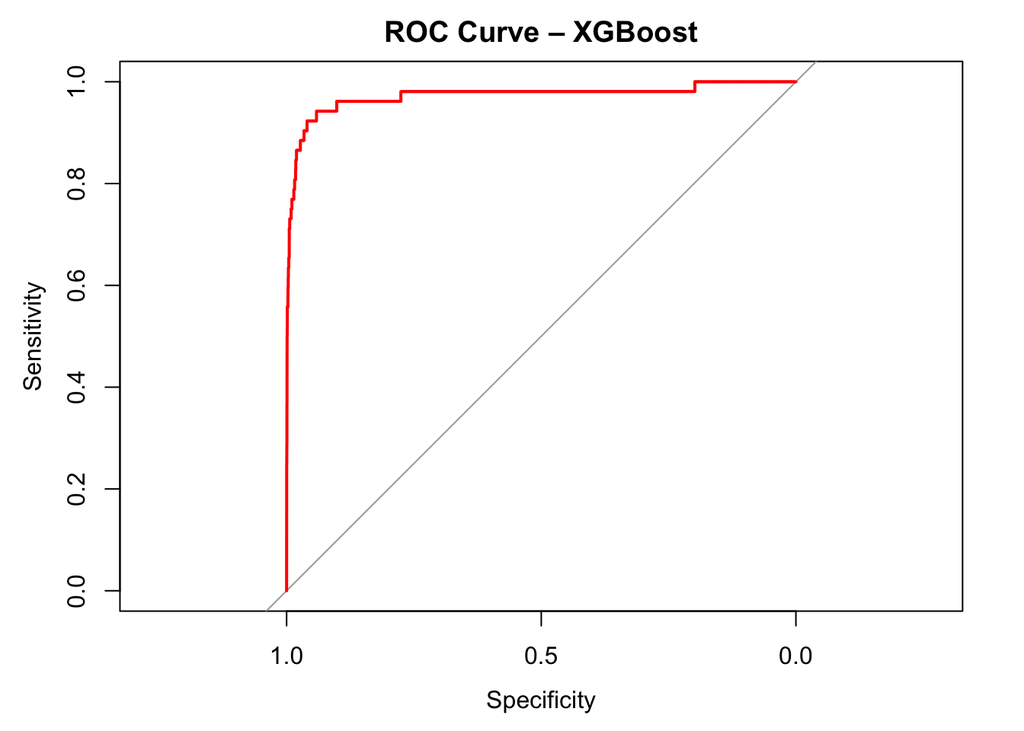

```r
plot(
  roc_xgb,
  col = "red",
  lwd = 2,
  main = "ROC Curve – XGBoost"
)
```

## 4.1 Evaluation at operational threshold

```r
library(caret)
y_test_fac <- factor(y_test,
                     levels = c(0,1),
                     labels = c("Non-fraud","Fraud"))

pred_fac <- factor(ifelse(xgb_prob >= 0.5, 1, 0),
                   levels = c(0,1),
                   labels = c("Non-fraud","Fraud"))

conf_mat <- confusionMatrix(pred_fac, y_test_fac, positive = "Fraud")

conf_mat
```

```
## Confusion Matrix and Statistics
##
##            Reference
## Prediction  Non-fraud Fraud
##   Non-fraud     29934    37
##   Fraud            14    15
##
##                Accuracy : 0.9983
##                  95% CI : (0.9978, 0.9987)
##     No Information Rate : 0.9983
##     P-Value [Acc > NIR] : 0.481509
##
##                   Kappa : 0.3696
##
##  Mcnemar's Test P-Value : 0.002066
##
##             Sensitivity : 0.2884615
##             Specificity : 0.9995325
##          Pos Pred Value : 0.5172414
##          Neg Pred Value : 0.9987655
##              Prevalence : 0.0017333
##          Detection Rate : 0.0005000
##    Detection Prevalence : 0.0009667
##       Balanced Accuracy : 0.6439970
##
##        'Positive' Class : Fraud
##
```

```r
precision <- conf_mat$byClass["Pos Pred Value"]
recall    <- conf_mat$byClass["Sensitivity"]
F1        <- 2 * precision * recall / (precision + recall)

precision
```

```
## Pos Pred Value
##      0.5172414
```

```r
recall
```

```
## Sensitivity
##   0.2884615
```

```r
F1
```

```
## Pos Pred Value
##      0.3703704
```

Because the dataset is highly imbalanced, accuracy is not meaningful. Besides ROC-AUC, we report precision, recall, F1, and PR-AUC, which better reflect performance on the fraud (positive) class. Recall and F1 are emphasized because missing frauds is more costly than flagging normal transactions. We also include threshold optimization to find the cutoff that gives the best balance between recall and precision.

## 4.2 Precision–Recall Curve and PR-AUC

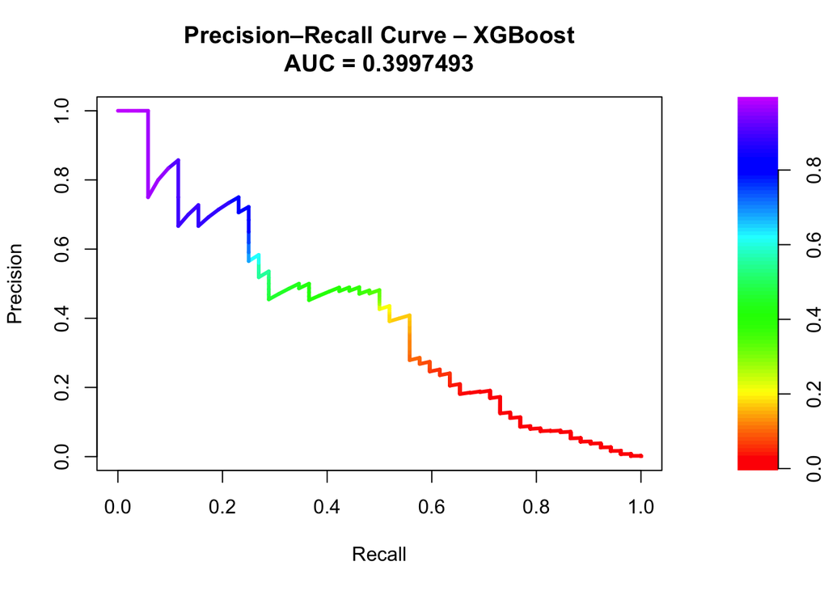

```r
library(PRROC)

fg <- xgb_prob[y_test == 1]  # fraud scores
bg <- xgb_prob[y_test == 0]  # non-fraud scores

pr_obj <- pr.curve(
  scores.class0 = fg,
  scores.class1 = bg,
  curve = TRUE
)

plot(pr_obj, main = "Precision–Recall Curve – XGBoost")
```

```r
pr_obj$auc.integral   # PR-AUC
```

```
## [1] 0.3997493
```

## 4.3 Threshold Optimization (find best F1)

```r
thresholds <- seq(0.05, 0.95, by=0.01)

results <- data.frame(
  threshold = thresholds,
  precision = NA,
  recall = NA,
  F1 = NA
)

for(i in seq_along(thresholds)) {
  t <- thresholds[i]

  pred_t <- factor(ifelse(xgb_prob >= t, 1, 0),
                   levels = c(0,1),
                   labels = c("Non-fraud","Fraud"))

  cm_t <- confusionMatrix(pred_t, y_test_fac, positive = "Fraud")

  p <- cm_t$byClass["Pos Pred Value"]
  r <- cm_t$byClass["Sensitivity"]
  f <- 2 * p * r / (p + r)

  results$precision[i] <- p
  results$recall[i] <- r
  results$F1[i] <- f
}

best_idx <- which.max(results$F1)
best_threshold <- results$threshold[best_idx]
best_threshold
```

```
## [1] 0.33
```

```r
results[best_idx,]
```

```
##    threshold precision recall       F1
## 29      0.33 0.4814815    0.5 0.490566
```